# Anatomy of a Pop Song in the 2010s

# Introduction

Billboard Year-End charts are a cumulative measure of a single or album's performance in the United States, based upon the Billboard magazine charts during any given chart year. The site is a leading figure in the music industry for ranking albums, artists, songs and even providing news. The Year-End chart, accumulated based on radio play, online streaming and album sales, is as good a metric as any to analyze the popular trends of music.

The goal of this experiment is to analyze the anatomy of all the songs of the last 10 years that charted on the Year-End list based on their characteristics from the Spotify API. We compile all the audio features given to us by Spotify and attempt to form a model to ultimately predict a song's position on the Billboard year-end chard, giving some order to the chaotic nature of popular music.

We assert that there is some relationship between year and a song's characteristics that predicts popularity on Spotify and then another relationship between year and popularity that determines the ultimate rank.

##### Can you reverse engineer a pop song?

# General Imports and Setup

###### Documentation:

[numpy](https://numpy.org/)  
[bs4](https://www.crummy.com/software/BeautifulSoup/bs4/doc/)  
[pandas](https://pandas.pydata.org/)  
[matplotlib](https://matplotlib.org/)  
[seaborn](https://seaborn.pydata.org/)

```python
import numpy as np
import requests
from bs4 import BeautifulSoup as bs
import pandas as pd
import matplotlib.pyplot as plt
import seaborn as sns
```

[SpotiPy Documentation](https://spotipy.readthedocs.io/en/latest/)

```python
import spotipy
import os
from spotipy.oauth2 import SpotifyClientCredentials

CLIENT_ID = os.environ['client_id']
CLIENT_SECRET = os.environ['client_secret']

client_credentials_manager = SpotifyClientCredentials(client_id=CLIENT_ID, client_secret=CLIENT_SECRET)
sp = spotipy.Spotify(client_credentials_manager=client_credentials_manager)
```

# Data Scraping from Billboard.com

```python
songs = []
artists = []
ranks = []
years = []
for YEAR in range(2010,2020):
    req = requests.get("https://www.billboard.com/charts/year-end/{}/hot-100-songs".format(YEAR))
    raw = bs(req.content, 'html.parser')
    s = raw.findAll("div",{"class":"ye-chart-item__title"})
    a = raw.findAll("div",{"class":"ye-chart-item__artist"})
    r = raw.findAll("div",{"class":"ye-chart-item__rank"})

    songs.extend([i.text.strip() for i in s])
    artists.extend([i.text.strip() for i in a])
    ranks.extend([i.text.strip() for i in r])
    years.extend([YEAR for i in r])
df = pd.DataFrame()
df['Rank'] = ranks
df['Song'] = songs
df['Artist'] = artists
df['Year'] = years
df
```

|  | Rank | Song | Artist | Year |
| --- | --- | --- | --- | --- |
| 0 | 1 | TiK ToK | Ke$ha | 2010 |
| 1 | 2 | Need You Now | Lady Antebellum | 2010 |
| 2 | 3 | Hey, Soul Sister | Train | 2010 |
| 3 | 4 | California Gurls | Katy Perry Featuring Snoop Dogg | 2010 |
| 4 | 5 | OMG | Usher Featuring will.i.am | 2010 |
| ... | ... | ... | ... | ... |
| 993 | 96 | Eyes On You | Chase Rice | 2019 |
| 994 | 97 | All To Myself | Dan + Shay | 2019 |
| 995 | 98 | Boyfriend | Ariana Grande & Social House | 2019 |
| 996 | 99 | Walk Me Home | P!nk | 2019 |
| 997 | 100 | Robbery | Juice WRLD | 2019 |

998 rows × 4 columns

For each year from 2010 to 2019, we can retrieve the html via a GET request and then begin to parse the DOM using BeautifulSoup. We strip the inner texts of each respective rank, artist, and song before placing them into one DataFrame.

```python
def get_audio_features(saved_uris):
    artist = []
    track = []
    danceability = []
    energy = []
    key = []
    loudness = []
    mode = []
    speechiness = []
    acousticness = []
    instrumentalness = []
    liveness = []
    valence = []
    tempo = []
    duration_ms = []
    popularity = []
    explicit = []

    for uri in saved_uris:
        if uri is not None:
            x = sp.audio_features(uri)
            y = sp.track(uri)
            for audio_features in x:
                danceability.append(audio_features['danceability'])
                energy.append(audio_features['energy'])
                key.append(audio_features['key'])
                loudness.append(audio_features['loudness'])
                mode.append(audio_features['mode'])
                speechiness.append(audio_features['speechiness'])
                acousticness.append(audio_features['acousticness'])
                instrumentalness.append(audio_features['instrumentalness'])
                liveness.append(audio_features['liveness'])
                valence.append(audio_features['valence'])
                tempo.append(audio_features['tempo'])
                duration_ms.append(audio_features['duration_ms'])

            artist.append(y['album']['artists'][0]['name'])
            track.append(y['name'])
            popularity.append(y['popularity'])
            explicit.append(1 if y['explicit'] == True else 0)
        else:
            danceability.append(np.nan)
            energy.append(np.nan)
            key.append(np.nan)
            loudness.append(np.nan)
            mode.append(np.nan)
            speechiness.append(np.nan)
            acousticness.append(np.nan)
            instrumentalness.append(np.nan)
            liveness.append(np.nan)
            valence.append(np.nan)
            tempo.append(np.nan)
            duration_ms.append(np.nan)
            artist.append(np.nan)
            track.append(np.nan)
            popularity.append(np.nan)
            explicit.append(np.nan)

    df = pd.DataFrame()
    df['artist'] = artist
    df['track'] = track
    df['popularity'] = popularity
    df['danceability'] = danceability
    df['energy'] = energy
    df['key'] = key
    df['loudness'] = loudness
    df['mode'] = mode
    df['speechiness'] = speechiness
    df['acousticness'] = acousticness
    df['instrumentalness'] = instrumentalness
    df['liveness'] = liveness
    df['valence'] = valence
    df['tempo'] = tempo
    df['duration_ms'] = duration_ms
    df['explicit'] = explicit

    return df
```

We define a function that, given a list of Spotify track IDs, can use Spotipy to search each one up and retrieve a number of characteristics. These characteristic are stored in a new DataFrame which is returned. We append a row full of NaNs if the uri given is NoneType. This will be discussed more below, but this is a graceful handling of the case where Spotipy cannot find the track.

```python
exceptions = ['a', 'an', 'of', 'the', 'is', 'but', 'as', 'at',
                    'in', 'on', 'to', 'and', 'from', 'out', 'for', 'with', 'into']
def titlecase(s):
    word_list = s.split(' ')
    final = [word_list[0][0].capitalize() + word_list[0][1:]]
    for word in word_list[1:]:
        final.append(word if word in exceptions else word[0].capitalize()+word[1:])
    return " ".join(final)
```

We define a function titlecase, that takes a string s and capitalizes the first letter of each word, provided it is not one of the exceptions which are lowercase in titles.

**Note: Python's string.title() function shouldn't be used as it ensures that ONLY the first letter of each word is capitalized. We cannot accept this condition as this format cannot be guaranteed in the names of all artists or songs. For example, ASAP Rocky**

# Helper Functions

```python
def just_the_artist(result):
    if "Featuring" in result:
        result = result.split(" Featuring",1)[0]
    if "&" in result:
        result = result.split(" &",1)[0]
    if ' X' in result:
        result = result.split(' X',1)[0]
    if ' x ' in result:
        result = result.split(' x',1)[0]
    if "/" in result:
        result = result.split(" /",1)[0]
    if "," in result:
        result = result.split(",",1)[0]
    if "+" in result:
        result = result.split(" +",1)[0]
    if "Duet" in result:
        result = result.split(" Duet",1)[0]
    if "With" in result:
        result = result.split(" With",1)[0]
    result = result.replace('*', '')
    result = result.replace('$', 's')
    result = result.replace('AsAP', 'ASAP')
    if 'Fun.' in result or 'fun.' in result: return 'fun.'
    if 'East Movement' in result: return 'Far East Movement'
    if 'Jay-Z' in result or 'Jay Z' in result: return 'JAY-Z'
    if 'Twenty One' in result: return 'twenty one pilots'
    if 'D.R.A.M' in result: return 'DRAM'
    if 'B.o.b' in result: return 'B.o.B'
    if 'Leon' in result: return 'Kings of Leon'
    if 'Will.i.am' in result or 'will.i.am' in result : return 'will.i.am'
    if 'Cash Out' in result: return 'Ca$h Out'
    if '5 Seconds' in result: return '5 Seconds of Summer'
    if 'Zayn' in result: return 'ZAYN'
    return titlecase(result)
```

We define a utility function to cleanse a string artist for better results in the Spotify API search. The scraped data from Billboard.com cannot be sent straight into the Spotify API as it picky on what is considered the artist of a given song. Despite features and collaborations, the first artist listed is often considered the sole owner of a track. For example, 'California Gurls' by Katy Perry Featuring Snoop Dogg does not exist in Snoop Dogg's discography. For this reason, we cut off anything that could denote a feature.

In addition, we take care of some special cases found from running through the data. These are more cases of format from Billboard and Spotify not agreeing in some cases. This is a rough process and some songs will still fall through because the artist isn't formatted correctly. Some known cases are artists with accented letters in their name like Beyonce or Michael Buble.

```python
def just_the_title(result):
    result = result.replace('$','s')
    if "(" in result:
        result = result.split(" (", 1)[0]
    return result
```

We define another utility that cleans the song title in a similar way as the previous function cleaned the artist name. We first remove any dollar signs and replace them with s in the case of Ran$som by Lil Tecca and others.

We also provide a fix to some songs that would be dropped because they became popular off a soundtrack. For example, Post Malone's 'Sunflower' charted off the soundtrack for Spiderman: Into the Spiderverse and is therefore listed like that on Billboard. By cutting everything including and after the first '(' which would denote the soundtrack it came from, we change the track name to only 'Sunflower' which can be found on 'Hollywood is Bleeding', Post Malone's most recent album. Unfortunately, some songs like 'Pray for Me' by the Weeknd only appear on the movie soundtrack and therefore can't be found.

```python
def get_album_uris(artist):
    q = '{}'.format(artist)
    results = sp.search(q=q, type = 'album', limit = 20)
    album_uris = []
    for i in range(len(results['albums']['items'])):
            album_uris.append(results['albums']['items'][i]['uri'])
    return album_uris
```

We define another helper method that takes an artist as a string and searches for their albums using a GET request. It then appends the uris (Uniform Resource Indicator) to a list and returns them. It is important to note that this search returns the first 20 albums that are either by the artist searched or contain the artist in their title.

```python
def find_song(track, uris, artist):
    for i in uris:
        for j in sp.album_tracks(i)['items']:
            if artist in j['artists'][0]['name']:
                if j['name'].startswith(track):
                    uri = j['uri']
                    return uri
    return None
```

Given a string track, an artist, and a list of album uris found from a call to get_album_uris(), find_song() searches through each album for a match. We search through each album and then in each song to see if the names of the parameter track and found track are similar enough to be deemed a match. We use startswith() to avoid potentially missing a song because of bad formatting done elsewhere.

We need to check if the track is performed by the specific artist desired to ensure that covers are not taken as the original song.

```python
def attempt(track, artist, albums):
    uri = find_song(track, albums, artist)
    #Title Case
    if uri is None:
        track = track.lower()
        uri = find_song(titlecase(track), albums, artist)
    #lowercase
    if uri is None:
        uri = find_song(track.lower(), albums, artist)
    #First Word Capital
    if uri is None:
        uri = find_song(track.title(), albums, artist)
    #Uppercase
    if uri is None:
        uri = find_song(track.upper(), albums, artist)
    return uri
```

We define yet another helper function that attempts to find the parameter song in the found album uris with various potential formats. At each step, we change what is capitalized and attempt to find that song in the albums. Checking that artists match in find_song() becomes crucial here as the correct song may be found on the all uppercase attempt, but a cover may be found on the 20th album of the 3rd attempt.

The uri returned may be null, but this is handled in get_audio_features().

Additionally, it is worth noting that we should not do the same procedure for attempting different artist formats as each different formatting would prompt a new query to the Spotify API. Here, since we already have the album uris, it is not as expensive.

```python
def get_uris(df):
    uris = []
    for _, row in df.iterrows():
        track = just_the_title(row['Song'])
        artist = just_the_artist(row['Artist'])
        albums = get_album_uris(artist)
        uri = attempt(track, artist, albums)
        uris.append(uri)
    return uris
```

We define one last helper method that takes in a dataframe and returns the track uris that correspond to tracks and artists given. It formats input using just_the_title() and just_the_artist() before attempting to find the correct uri.

# Retrieving Data from Spotify

```python
uris = get_uris(df)
np.save('uris', uris)
```

We call get_uris() with the dataframe containing top 100 songs from the last 10 years. This is a lengthy process, so it makes sense to save the file locally to avoid needing to rerun to retrieve the same data.

In addition to the few cases mentioned before where an artist wouldn't be found, some other known drop cases include:

- Songs that appear on an album or single whose 'artist' is a group or all parties involved and so nobody has direct ownership.
- Songs with unusual capitalization like I hate U, I love U by gnash.
- Songs that aren't on Spotify for one reason or another like eenie meenie by Sean Kingston.
- Clean versions of explicit songs that have a completely different name on Billboard than on Spotify.
- Miscellaneous mysterious drop cases that have no logical explanation like It Will Rain by Bruno Mars.

In the end, the above program retrieves about 95% of songs listed in the initial dataframe which is plenty for meaningful analysis.

```python
saved_uris = np.load('uris.npy', allow_pickle=True)
```

We can load the uris from a file to avoid having to rerun lengthy code.

```python
data = get_audio_features(saved_uris)
data['year'] = df['Year']
data['billboard_rank'] = df['Rank']
data.to_csv('song_data.csv', index=False)
```

```python
data.head()
```

|  | artist | track | popularity | danceability | energy | key | loudness | mode | speechiness | acousticness | instrumentalness | liveness | valence | tempo | duration_ms | explicit | year | billboard_rank |
| --- | --- | --- | --- | --- | --- | --- | --- | --- | --- | --- | --- | --- | --- | --- | --- | --- | --- | --- |
| 0 | Kesha | TiK ToK | 80.0 | 0.755 | 0.837 | 2.0 | -2.718 | 0.0 | 0.1420 | 0.09910 | 0.000000 | 0.2890 | 0.714 | 120.028 | 199693.0 | 0.0 | 2010 | 1 |
| 1 | Lady Antebellum | Need You Now | 69.0 | 0.587 | 0.622 | 4.0 | -5.535 | 1.0 | 0.0303 | 0.09270 | 0.000636 | 0.2000 | 0.231 | 107.943 | 277573.0 | 0.0 | 2010 | 2 |
| 2 | Train | Hey, Soul Sister | 84.0 | 0.673 | 0.886 | 1.0 | -4.440 | 0.0 | 0.0431 | 0.18500 | 0.000000 | 0.0826 | 0.795 | 97.012 | 216773.0 | 0.0 | 2010 | 3 |
| 3 | Katy Perry | California Gurls | 72.0 | 0.791 | 0.754 | 0.0 | -3.729 | 1.0 | 0.0569 | 0.00446 | 0.000000 | 0.1630 | 0.425 | 125.014 | 234653.0 | 0.0 | 2010 | 4 |
| 4 | Usher | OMG (feat. will.i.am) | 72.0 | 0.781 | 0.745 | 4.0 | -5.810 | 0.0 | 0.0332 | 0.19800 | 0.000011 | 0.3600 | 0.326 | 129.998 | 269493.0 | 0.0 | 2010 | 5 |

We use the Spotify API to get characteristics (features) of each song and store the dataframe in a local CSV file called [song_data.csv] for easier access. We also append billboard rank and year from the first dataframe.

**Note: Songs that couldn't be found are still in this new dataframe with NaN values for each column. Because of this, the dataframe is still the same size as the initial one from billboard and each song's year and billboard rank still match up.**

```python
data = pd.read_csv('song_data.csv')
```

We can load data from the created csv file to avoid reruning lengthy code.

```python
data = data.dropna().reset_index(drop=True)
data
```

|  | artist | track | popularity | danceability | energy | key | loudness | mode | speechiness | acousticness | instrumentalness | liveness | valence | tempo | duration_ms | explicit | year | billboard_rank |
| --- | --- | --- | --- | --- | --- | --- | --- | --- | --- | --- | --- | --- | --- | --- | --- | --- | --- | --- |
| 0 | Kesha | TiK ToK | 80.0 | 0.755 | 0.837 | 2.0 | -2.718 | 0.0 | 0.1420 | 0.09910 | 0.000000 | 0.2890 | 0.714 | 120.028 | 199693.0 | 0.0 | 2010 | 1 |
| 1 | Lady Antebellum | Need You Now | 69.0 | 0.587 | 0.622 | 4.0 | -5.535 | 1.0 | 0.0303 | 0.09270 | 0.000636 | 0.2000 | 0.231 | 107.943 | 277573.0 | 0.0 | 2010 | 2 |
| 2 | Train | Hey, Soul Sister | 84.0 | 0.673 | 0.886 | 1.0 | -4.440 | 0.0 | 0.0431 | 0.18500 | 0.000000 | 0.0826 | 0.795 | 97.012 | 216773.0 | 0.0 | 2010 | 3 |
| 3 | Katy Perry | California Gurls | 72.0 | 0.791 | 0.754 | 0.0 | -3.729 | 1.0 | 0.0569 | 0.00446 | 0.000000 | 0.1630 | 0.425 | 125.014 | 234653.0 | 0.0 | 2010 | 4 |
| 4 | Usher | OMG (feat. will.i.am) | 72.0 | 0.781 | 0.745 | 4.0 | -5.810 | 0.0 | 0.0332 | 0.19800 | 0.000011 | 0.3600 | 0.326 | 129.998 | 269493.0 | 0.0 | 2010 | 5 |
| ... | ... | ... | ... | ... | ... | ... | ... | ... | ... | ... | ... | ... | ... | ... | ... | ... | ... | ... |
| 938 | Chase Rice | Eyes On You | 76.0 | 0.606 | 0.652 | 9.0 | -6.982 | 1.0 | 0.0281 | 0.32300 | 0.000000 | 0.2010 | 0.476 | 97.155 | 182493.0 | 0.0 | 2019 | 96 |
| 939 | Dan + Shay | All To Myself | 75.0 | 0.646 | 0.781 | 1.0 | -4.616 | 1.0 | 0.0313 | 0.20800 | 0.000000 | 0.1250 | 0.565 | 94.975 | 169920.0 | 0.0 | 2019 | 97 |
| 940 | Ariana Grande | boyfriend (with Social House) | 88.0 | 0.400 | 0.795 | 10.0 | -3.731 | 0.0 | 0.4610 | 0.11900 | 0.000000 | 0.1590 | 0.702 | 190.097 | 186107.0 | 1.0 | 2019 | 98 |
| 941 | P!nk | Walk Me Home | 64.0 | 0.652 | 0.453 | 1.0 | -6.119 | 1.0 | 0.0445 | 0.05190 | 0.000000 | 0.1790 | 0.432 | 88.038 | 177391.0 | 0.0 | 2019 | 99 |
| 942 | Juice WRLD | Robbery | 90.0 | 0.685 | 0.692 | 2.0 | -5.122 | 1.0 | 0.0457 | 0.32800 | 0.000000 | 0.1530 | 0.578 | 159.966 | 240051.0 | 1.0 | 2019 | 100 |

943 rows × 18 columns

We drop the songs that couldn't be found and are left with only the songs with all of the features found.

# Analyzing the Relationship Between Billboard Rank and Spotify Popularity

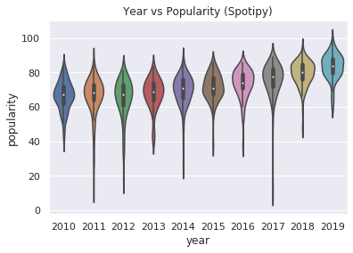

```python
sns.set(style = 'darkgrid')
sns.violinplot(x='year', y = 'popularity', data = data).set_title("Year vs Popularity (Spotipy)")
```

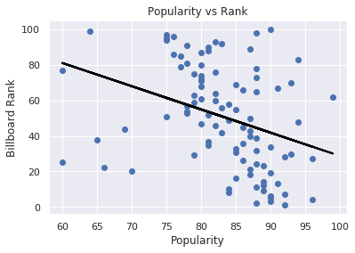

```python
small_data = data[data['year']==2019]
x = small_data['popularity']
y = small_data['billboard_rank']
plt.scatter(x, y)
plt.xlabel("Popularity")
plt.ylabel("Billboard Rank")
plt.title('Popularity vs Rank')

fit = np.polyfit(x, y, 1)
fit_fn = np.poly1d(fit)
plt.plot(x, fit_fn(x), linewidth=2, color = 'black')
plt.show()
#This sucks
```

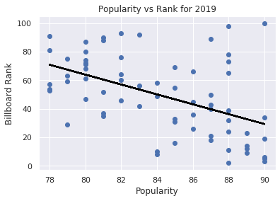

```
Slope: -3.4604616573586635, Intercept: 340.79622041732864
```

```python
data2019 = data[data['year'] == 2019]
first = np.percentile(data2019['popularity'], 15)
last = np.percentile(data2019['popularity'], 85)
small_data = data2019[(data2019['popularity'] >= first) & (data2019['popularity'] <= last)]

x = small_data['popularity']
y = small_data['billboard_rank']
plt.scatter(x, y)
plt.xlabel("Popularity")
plt.ylabel("Billboard Rank")
plt.title('Popularity vs Rank for 2019')

fit = np.polyfit(x, y, 1)
fit_fn = np.poly1d(fit)
plt.plot(x, fit_fn(x), linewidth=2, color = 'black')
plt.show()
print("Slope: {}, Intercept: {}".format(fit[0], fit[1]))
```

To solve this, we use numpy to find the 15th and 85th percentile and only fit for these points. As the graph for 2019 shows, the best fit line is much more representative of the general trend.

```
2010; Slope: -3.2338016837628873, Intercept: 267.7985805821332
2011; Slope: -2.4448002495733285, Intercept: 219.8538252619594
2012; Slope: -2.3554812857928042, Intercept: 209.32511834896536
2013; Slope: -1.5261475751540154, Intercept: 160.9078929084257
2014; Slope: -2.53315035946173, Intercept: 232.28173197058766
2015; Slope: 0.20553211758302312, Intercept: 39.461520141534585
2016; Slope: -1.856219392752199, Intercept: 190.81292850146872
2017; Slope: -2.0814407769826206, Intercept: 210.60782094347894
2018; Slope: -2.4043707903280356, Intercept: 242.40630905654763
2019; Slope: -3.4604616573586635, Intercept: 340.79622041732864
```

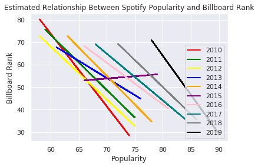

```python
cs = ['red', 'green', 'yellow', 'blue', 'orange', 'purple', 'pink', 'teal', 'gray', 'black']
slopes = []
intercepts = []
for YEAR in range(2010, 2020):
    data_by_year = data[data['year'] == YEAR]
    first = np.percentile(data_by_year['popularity'], 15)
    last = np.percentile(data_by_year['popularity'], 85)
    small_data = data_by_year[(data_by_year['popularity'] >= first) & (data_by_year['popularity'] <= last)]

    x = small_data['popularity']
    y = small_data['billboard_rank']

    fit = np.polyfit(x, y, 1)
    fit_fn = np.poly1d(fit)
    plt.plot(x, fit_fn(x), linewidth=2, color = cs[YEAR - 2010], label = "{}".format(YEAR))
    slopes.append(fit[0])
    intercepts.append(fit[1])
    print("{}; Slope: {}, Intercept: {}".format(YEAR, fit[0], fit[1]))
plt.legend(loc='lower right')
plt.xlabel('Popularity')
plt.ylabel('Billboard Rank')
plt.title('Estimated Relationship Between Spotify Popularity and Billboard Rank')
plt.show()
```

We then expand the analysis to find the best fit lines for all the years in the data set. We can see that most of the years have a similar linear relationship between higher rank on the charts and higher popularity except for 2015 which is unusually scattered.

```python
popped = slopes.pop(5)
popped = intercepts.pop(5)
years = [i for i in range(2010,2020)]
popped = years.pop(5)
```

We drop 2015 from this analysis which can be seen as an outlier in both slope and intercept.

[python.random documentation](https://docs.python.org/3/library/random.html)

```python
from random import seed
from random import random

s_fit = np.polyfit(years, slopes, 1)
i_fit = np.polyfit(years, intercepts, 1)
s_fit_fn = np.poly1d(s_fit)
i_fit_fn = np.poly1d(i_fit)

def billboard_rank_guesser(year):
    def guess(x):
        return s_fit_fn(year) * x + i_fit_fn(year)
    return guess

seed(1)
for _ in range(10):
    value = int(random() * len(data.index - 1))
    test = data.iloc[value]
    test_pop = test.popularity
    act_rank = test.billboard_rank

    fn = billboard_rank_guesser(test.year)
    print("Rank prediction for {} by {} in {}: {}. Was actually: {}"
          .format(test.track, test.artist, test.year, fn(test_pop), act_rank))
```

```
Rank prediction for Lighters by Bad Meets Evil in 2011: 43.058320957542605. Was actually: 34
Rank prediction for All The Stars (with SZA) by Kendrick Lamar in 2018: 53.352910446880685. Was actually: 47
Rank prediction for Passionfruit by Drake in 2017: 45.99220581021518. Was actually: 65
Rank prediction for Wanted by Hunter Hayes in 2012: 48.04394597016821. Was actually: 52
Rank prediction for Believe Me by Lil Wayne in 2014: 75.02116680527229. Was actually: 89
Rank prediction for Show Me (feat. Chris Brown) by Kid Ink in 2014: 53.15634719260197. Was actually: 43
Rank prediction for Into You by Ariana Grande in 2016: 41.091979733453314. Was actually: 51
Rank prediction for Malibu by Miley Cyrus in 2017: 53.35035087105453. Was actually: 89
Rank prediction for American Honey by Lady Antebellum in 2010: 47.66617691656444. Was actually: 94
Rank prediction for Breakeven by The Script in 2010: 23.68247448744586. Was actually: 27
```

We fit a new line of best fit to both slopes and intercepts given years. We can then define a function billboard_rank_guesser() that, given a year, can return a best fit function that in turn guesses billboard rank given spotify popularity.

### Conclusion

In general, we found that other factors that are taken to account in Billboard's ranking either did not change much in this decade or have very little effect on their rank compared to raw plays. These factors include music video views, album sales and radio play. We can attribute this to the increasingly mobile nature of music. The portability of Spotify (and its competitors like Pandora and Apple Music) and the volume of play that allows becomes a strong indicator for general popularity.

# Data Feature Analysis

###### Useful Links:

[sklearn Documentation](https://scikit-learn.org/stable/getting_started.html)  
[More about Linear Regression](http://www.stat.yale.edu/Courses/1997-98/101/linreg.htm)  
[More about K-Nearest Neighbour Regression](https://www.analyticsvidhya.com/blog/2018/08/k-nearest-neighbor-introduction-regression-python/)  
[More about Support Vector Regression](https://www.saedsayad.com/support_vector_machine_reg.htm)

### Comparing Various Regression Algorithms

Now we begin to analyze the role of each feature in determining the popularity of a song. This will allow us to run regression algorithms on our features that could predict the popularity of a song given its features, which we could then pipe into our previous algorithm to predict its billboard rank in a given year.

```python
data.head()
```

|  | artist | track | popularity | danceability | energy | key | loudness | mode | speechiness | acousticness | instrumentalness | liveness | valence | tempo | duration_ms | explicit | year | billboard_rank |
| --- | --- | --- | --- | --- | --- | --- | --- | --- | --- | --- | --- | --- | --- | --- | --- | --- | --- | --- |
| 0 | Kesha | TiK ToK | 80.0 | 0.755 | 0.837 | 2.0 | -2.718 | 0.0 | 0.1420 | 0.09910 | 0.000000 | 0.2890 | 0.714 | 120.028 | 199693.0 | 0.0 | 2010 | 1 |
| 1 | Lady Antebellum | Need You Now | 69.0 | 0.587 | 0.622 | 4.0 | -5.535 | 1.0 | 0.0303 | 0.09270 | 0.000636 | 0.2000 | 0.231 | 107.943 | 277573.0 | 0.0 | 2010 | 2 |
| 2 | Train | Hey, Soul Sister | 84.0 | 0.673 | 0.886 | 1.0 | -4.440 | 0.0 | 0.0431 | 0.18500 | 0.000000 | 0.0826 | 0.795 | 97.012 | 216773.0 | 0.0 | 2010 | 3 |
| 3 | Katy Perry | California Gurls | 72.0 | 0.791 | 0.754 | 0.0 | -3.729 | 1.0 | 0.0569 | 0.00446 | 0.000000 | 0.1630 | 0.425 | 125.014 | 234653.0 | 0.0 | 2010 | 4 |
| 4 | Usher | OMG (feat. will.i.am) | 72.0 | 0.781 | 0.745 | 4.0 | -5.810 | 0.0 | 0.0332 | 0.19800 | 0.000011 | 0.3600 | 0.326 | 129.998 | 269493.0 | 0.0 | 2010 | 5 |

A look back at our data

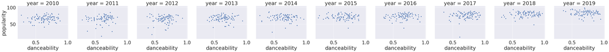

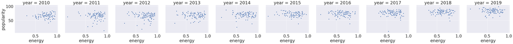

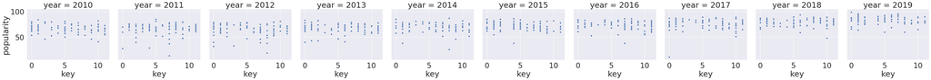

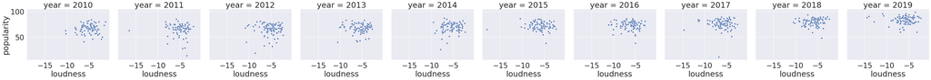

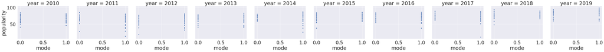

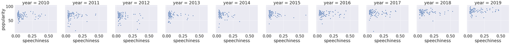

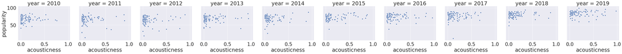

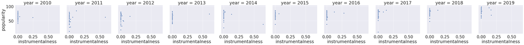

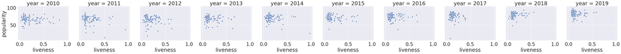

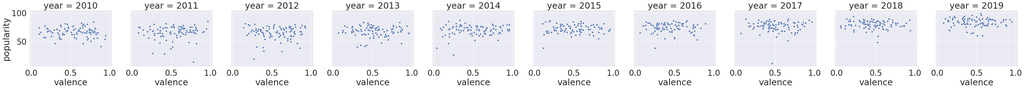

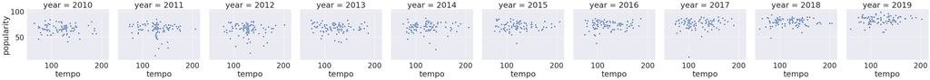

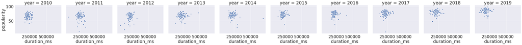

```python
features=['danceability', 'energy', 'key', 'loudness', 'mode', 'speechiness', 'acousticness', 'instrumentalness', 'liveness', 'valence', 'tempo', 'duration_ms']
for feature in data.columns:
    if feature in features:
        sns.set(font_scale=2.5)
        plot = sns.relplot(data=data, x=feature, y='popularity', col='year')
plot.fig.set_size_inches(50,5)
```

After extracting the specific features that we've been analyzing, we create plots for each [popularity, feature, year] combination. Each row of this multiplot allows us to visualize the the relationship between a feature and its impact on popularity from 2010-2019. A few notable changes are in loudness, where increasing loudness seems to cause an increase in popularity over the years, and in danceability, where initially the amount of danceability didn't seem to affect popularity (as it about evenly disperesed) but in recent years has seen a more positive correlation with popularity.

### Feature Correlation Matrix

```python
from sklearn.preprocessing import Normalizer
normalized = Normalizer().fit_transform(data[data.select_dtypes('float').columns])

norm_df = pd.DataFrame(normalized)
norm_df.columns = data[data.select_dtypes('float').columns].columns
```

We import the Normalizer package to normalize the numeric values in our dataframe, allowing us to effectively create a correlation matrix and visualize the possible correlations between each feature.

```python
import matplotlib.cm as cm
def plot_corr(df):
    corr = df.corr()
    fig, ax = plt.subplots(figsize=(10, 10))
    ax.matshow(corr)

    plt.xticks(rotation=50)
    plt.xticks(range(len(corr.columns)), corr.columns);
    plt.yticks(range(len(corr.columns)), corr.columns);
    plt.show()
```

We create this function to handle our correlation matrix creation.

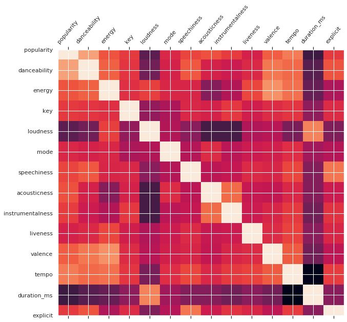

```python
sns.set(font_scale=1)
plot_corr(norm_df)
```

### Linear Regression Coefficient Dataframe

We now create and run regression algorithms on our dataset to analyze each feature's impact on popularity.

```python
from sklearn.linear_model import LinearRegression
from sklearn import svm

linear_coef_df = pd.DataFrame(columns=['year', 'popularity_intercept', 'danceability', 'energy', 'key', 'loudness', 'mode', 'speechiness', 'acousticness', 'instrumentalness', 'liveness', 'valence', 'tempo', 'duration_ms'])
svm_coef_df = pd.DataFrame(columns=['year', 'popularity_intercept', 'danceability', 'energy', 'key', 'loudness', 'mode', 'speechiness', 'acousticness', 'instrumentalness', 'liveness', 'valence', 'tempo', 'duration_ms'])

for year in range(2010,2020):
    year_data = data[data['year']==year]
    X = year_data[['danceability', 'energy', 'key', 'loudness', 'speechiness', 'mode', 'acousticness', 'instrumentalness', 'liveness', 'valence', 'tempo', 'duration_ms']]
    Y = year_data['popularity']

    linear_mdl = LinearRegression().fit(X, Y)
    linear_mdl.coef_ = np.insert(linear_mdl.coef_, 0, year)
    linear_mdl.coef_ = np.insert(linear_mdl.coef_, 1, linear_mdl.intercept_)
    linear_coef_df = linear_coef_df.append(pd.Series(linear_mdl.coef_, index=linear_coef_df.columns), ignore_index=True)

    svm_mdl = svm.SVR(kernel='linear').fit(X, Y)
    svm_coefs = svm_mdl.coef_[0]
    svm_coefs = np.insert(svm_coefs, 0, year)
    svm_coefs = np.insert(svm_coefs, 1, svm_mdl.intercept_)
    svm_coef_df = svm_coef_df.append(pd.Series(svm_coefs, index=svm_coef_df.columns), ignore_index=True)
```

We take a look at two linear regression algorithsm-- the standard Linear Regression algorithm with squared loss, and the Support Vector Regression algorithm, which uses optimized hyperplanes to separate the data in multiple dimensions.

###### Linear Regression Coefficients

```python
display(linear_coef_df)
```

|  | year | popularity_intercept | danceability | energy | key | loudness | mode | speechiness | acousticness | instrumentalness | liveness | valence | tempo | duration_ms |
| --- | --- | --- | --- | --- | --- | --- | --- | --- | --- | --- | --- | --- | --- | --- |
| 0 | 2010.0 | 48.997011 | 18.153034 | 13.616237 | -0.351903 | -0.055680 | 13.582063 | 0.765873 | 2.996448 | -18.983845 | -8.087311 | -9.397201 | 0.002850 | 0.000009 |
| 1 | 2011.0 | 77.582568 | 9.120565 | -1.766228 | 0.241921 | -1.021827 | 16.251316 | -1.055580 | 2.445319 | -47.855949 | -16.629326 | 1.762186 | -0.029708 | -0.000073 |
| 2 | 2012.0 | 20.301817 | 27.646255 | -2.676941 | -0.234924 | -0.200332 | -43.385514 | 2.244120 | -8.937130 | -69.772990 | -4.649094 | -4.037380 | 0.038588 | 0.000140 |
| 3 | 2013.0 | 75.013164 | -9.132679 | -1.130100 | 0.029283 | 0.616110 | -4.763366 | 0.007632 | 4.269815 | 14.197778 | -4.901656 | 2.495789 | -0.036813 | 0.000027 |
| 4 | 2014.0 | 105.187874 | -11.838983 | -15.205992 | -0.522490 | 0.788754 | -28.765488 | -2.182531 | -4.551050 | -32.873040 | -15.882620 | 5.942022 | 0.003691 | -0.000028 |
| 5 | 2015.0 | 66.795221 | -0.088968 | -1.539337 | -0.286100 | 0.253335 | -9.715844 | 1.017079 | 7.411893 | 82.145457 | -0.406587 | 1.032080 | 0.006303 | 0.000029 |
| 6 | 2016.0 | 76.384481 | 5.365107 | -5.468921 | -0.304496 | 0.440936 | -3.029101 | -0.835236 | 0.754421 | 12.622307 | -4.740373 | -2.329771 | 0.032325 | 0.000001 |
| 7 | 2017.0 | 77.277064 | 5.397764 | -12.588445 | -0.070076 | 0.865132 | -7.051328 | -3.525627 | 4.717367 | 101.060719 | -5.559324 | 0.116260 | 0.051771 | 0.000021 |
| 8 | 2018.0 | 73.846442 | 6.950923 | -9.815491 | 0.327787 | 1.008339 | -3.306769 | 0.344395 | 7.819952 | 87.472306 | 16.274959 | -0.209369 | 0.023924 | 0.000021 |
| 9 | 2019.0 | 92.354545 | -7.167299 | -5.533222 | -0.242941 | 0.253496 | 9.682677 | -0.874282 | 2.730279 | 1.993247 | -5.006079 | 0.771330 | 0.027832 | -0.000011 |

###### SVM Coefficients

```python
display(svm_coef_df)
```

|  | year | popularity_intercept | danceability | energy | key | loudness | mode | speechiness | acousticness | instrumentalness | liveness | valence | tempo | duration_ms |
| --- | --- | --- | --- | --- | --- | --- | --- | --- | --- | --- | --- | --- | --- | --- |
| 0 | 2010.0 | 9939.953638 | 1.506897 | 1.705502 | -25.031135 | 14.391379 | -1.243495 | 0.577940 | 0.960429 | 0.210914 | 1.686536 | 2.044749 | -23.775881 | -0.047811 |
| 1 | 2011.0 | -27725.688885 | 0.359826 | -2.352998 | 4.211060 | -25.577552 | -1.692303 | -5.183058 | 3.662759 | 0.550131 | 0.691258 | -4.010050 | -4.310214 | 0.114965 |
| 2 | 2012.0 | 14748.257847 | 0.437164 | 0.349553 | 87.862482 | 4.336310 | -0.603899 | -2.000000 | 0.115518 | -0.093352 | 1.644585 | -2.110891 | -77.496405 | -0.022682 |
| 3 | 2013.0 | -268.858080 | -0.009857 | 0.444371 | -49.969089 | -2.406169 | -0.117415 | -6.390465 | -1.559681 | -0.599833 | 0.231973 | 0.241787 | -63.041375 | 0.029911 |
| 4 | 2014.0 | -45529.917447 | -1.028118 | 0.001079 | 15.436748 | -8.882386 | 0.326634 | 2.836768 | -0.060566 | -0.594489 | -0.183114 | 1.933739 | 43.071176 | 0.192854 |
| 5 | 2015.0 | 15484.806313 | 0.003470 | -1.927216 | 22.846193 | -13.930444 | 0.749118 | -4.000000 | -0.995797 | 0.052264 | 2.106531 | -1.252253 | 76.108802 | -0.095819 |
| 6 | 2016.0 | 10846.608132 | 0.743333 | -0.942604 | 52.876430 | -4.595765 | 1.133582 | -6.000000 | 1.382036 | 0.154192 | 0.980706 | 0.488343 | -48.019452 | -0.006979 |
| 7 | 2017.0 | -3856.644030 | -0.253454 | -1.735013 | 44.627112 | -26.253289 | 0.575843 | -5.810241 | -0.490736 | -0.191490 | -0.955349 | -1.479977 | -7.404303 | 0.011605 |
| 8 | 2018.0 | -10682.866762 | -0.674692 | 2.106882 | -21.000000 | 28.874965 | -0.118439 | -1.000000 | -2.501463 | 0.111580 | -0.613698 | 2.508785 | 120.433946 | -0.010233 |
| 9 | 2019.0 | 9668.419965 | 1.409267 | 0.195380 | -2.984504 | 0.107541 | -0.616576 | 2.000000 | -1.156532 | 0.183226 | -3.079891 | -0.897451 | -46.662954 | -0.020226 |

### Relative Impact of Song Features Through the Years

We now graph the model and its feature coefficients over the years in order to visualize how the model determined the relative impact of each feature for each year.

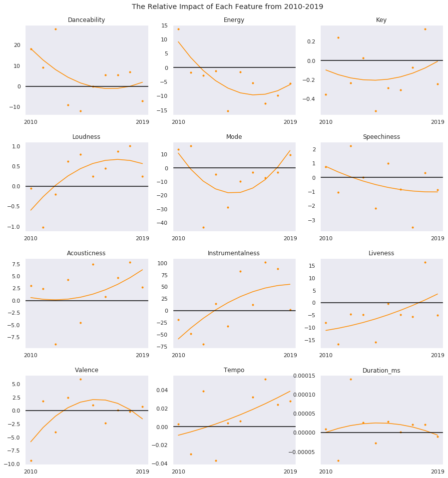

```python
features=['danceability', 'energy', 'key', 'loudness', 'mode', 'speechiness', 'acousticness', 'instrumentalness', 'liveness', 'valence', 'tempo', 'duration_ms']
i = 1
fig = plt.figure(figsize=(15,15))
sns.set(font_scale=1)
for feature in features:
    lin_y = list(linear_coef_df[feature])
    x = list(linear_coef_df['year'])

    ax = fig.add_subplot(4,3,i)
    ax.grid(False)
    ax.set_title(feature.capitalize())
    ax.plot(x, lin_y, marker='o', markersize=3, linewidth=0, color='darkorange')
    plt.xticks(np.arange(min(x), max(x)+1, max(x)-min(x)))

    lin_fit = np.polyfit(x, lin_y, 2)
    svm_fit = np.polyfit(x, svm_y, 2)

    lin_fit_fn = np.poly1d(lin_fit)

    ax.plot(x, lin_fit_fn(x), linewidth=1.5, color = 'darkorange') # plotting line of best fit
    ax.axhline(0, color='black')
    i+=1
plt.subplots_adjust(hspace=0.3, top=0.94)
plt.suptitle("The Relative Impact of Each Feature from 2010-2019")
plt.show()
```

Each of these graphs represents the change in correlation between each feature and year, and the second degree polynomial of best fit represent the general trend of impact each of these features has. For example a look at the Tempo graph tells us that in the years 2011 and 2013, an increase in tempo caused a decrease in popularity (because of the negative coefficient) but in every other year the two had a positive correlation. But more generally, over the 10 years, tempo has shifted from creating a negative impact on popularity to a positive impact on popularity. A similar analysis follows for Loudness where the years 2010-2012 saw a negative impact of loudness on popularity, but the later years so a positive impact, and the line of best fit indicates a general increase in the positive impact of loudness.

```python
from sklearn.model_selection import KFold, train_test_split,cross_val_score
from sklearn.neighbors import KNeighborsClassifier

kfold = KFold(10, True, 1)
linear_avg = []
linear_svm_avg = []
svm_avg = []
knn_avg = []

data = data[['year', 'popularity', 'danceability', 'energy', 'key', 'loudness', 'speechiness', 'mode', 'acousticness', 'instrumentalness', 'liveness', 'valence', 'tempo', 'duration_ms']]
data = data.reset_index(drop=True)
X = data.drop(['popularity'], axis=1)
Y = data['popularity']

for train, test in kfold.split(X):
    X_train, X_test = X.loc[train, :], X.loc[test, :]
    y_train, y_test = Y[train], Y[test]

    svm_mdl = svm.SVR(gamma='auto').fit(X_train, y_train)
    svm_acc = svm_mdl.score(X_test, y_test)

    linear_mdl = LinearRegression().fit(X_train, y_train)
    linear_acc = linear_mdl.score(X_test, y_test)

    knn_mdl = KNeighborsClassifier().fit(X_train, y_train)
    knn_acc = knn_mdl.score(X_test, y_test)

    linear_avg.append(linear_acc)
    svm_avg.append(svm_acc)
    knn_avg.append(knn_acc)

print("linear acc ", np.mean(linear_avg))
print("svm acc ", np.mean(svm_avg))
print("knn acc ", np.mean(knn_avg))
```

```
linear acc  0.265743475741396
svm acc  0.0069820320428157666
knn acc  0.028611422172452404
```

From the above results, we determine that the linear classifier performs with the best accuracy of the three regression algorithms. Thus, we continue our prediction with the linear model by using sklearn's LinearRegression.

```python
data = data[['year', 'popularity', 'danceability', 'energy', 'key', 'loudness', 'speechiness', 'mode', 'acousticness', 'instrumentalness', 'liveness', 'valence', 'tempo', 'duration_ms']]
data = data.reset_index(drop=True)
X = data.drop(['popularity'], axis=1)
Y = data['popularity']
linear_mdl = LinearRegression().fit(X_train, y_train)
```

We reset the data to the original

```python
data = pd.read_csv('song_data.csv')
data = data.dropna().reset_index(drop=True)
data.head()
```

|  | artist | track | popularity | danceability | energy | key | loudness | mode | speechiness | acousticness | instrumentalness | liveness | valence | tempo | duration_ms | explicit | year | billboard_rank |
| --- | --- | --- | --- | --- | --- | --- | --- | --- | --- | --- | --- | --- | --- | --- | --- | --- | --- | --- |
| 0 | Kesha | TiK ToK | 80.0 | 0.755 | 0.837 | 2.0 | -2.718 | 0.0 | 0.1420 | 0.09910 | 0.000000 | 0.2890 | 0.714 | 120.028 | 199693.0 | 0.0 | 2010 | 1 |
| 1 | Lady Antebellum | Need You Now | 69.0 | 0.587 | 0.622 | 4.0 | -5.535 | 1.0 | 0.0303 | 0.09270 | 0.000636 | 0.2000 | 0.231 | 107.943 | 277573.0 | 0.0 | 2010 | 2 |
| 2 | Train | Hey, Soul Sister | 84.0 | 0.673 | 0.886 | 1.0 | -4.440 | 0.0 | 0.0431 | 0.18500 | 0.000000 | 0.0826 | 0.795 | 97.012 | 216773.0 | 0.0 | 2010 | 3 |
| 3 | Katy Perry | California Gurls | 72.0 | 0.791 | 0.754 | 0.0 | -3.729 | 1.0 | 0.0569 | 0.00446 | 0.000000 | 0.1630 | 0.425 | 125.014 | 234653.0 | 0.0 | 2010 | 4 |
| 4 | Usher | OMG (feat. will.i.am) | 72.0 | 0.781 | 0.745 | 4.0 | -5.810 | 0.0 | 0.0332 | 0.19800 | 0.000011 | 0.3600 | 0.326 | 129.998 | 269493.0 | 0.0 | 2010 | 5 |

```python
features = ['year', 'danceability', 'energy', 'key', 'loudness', 'speechiness', 'mode', 'acousticness', 'instrumentalness', 'liveness', 'valence', 'tempo', 'duration_ms']
def predict_popularity(song):
    song = song[features]
    return linear_mdl.predict(song)
```

This function takes in a song from the dataframe and strips it down to just the features, which it then sends to the prediction model to predict the song's popularity given its year and musical features.

```python
seed(1)
for _ in range(10):
    value = int(random() * len(data.index - 1))
    test = data[value:value+1]
    test_pop = predict_popularity(test)
    act_rank = test.iloc[0].billboard_rank

    fn = billboard_rank_guesser(test.year)
    print("Rank prediction for {} by {} in {}: {}. Was actually: {}"
            .format(test.iloc[0].track, test.iloc[0].artist, test.iloc[0].year, fn(test_pop)[0], act_rank))
```

```
Rank prediction for Lighters by Bad Meets Evil in 2011: 51.62122696573883. Was actually: 34
Rank prediction for All The Stars (with SZA) by Kendrick Lamar in 2018: 58.070205434450486. Was actually: 47
Rank prediction for Passionfruit by Drake in 2017: 61.48410147027377. Was actually: 65
Rank prediction for Wanted by Hunter Hayes in 2012: 53.10684506172791. Was actually: 52
Rank prediction for Believe Me by Lil Wayne in 2014: 53.691066008450804. Was actually: 89
Rank prediction for Show Me (feat. Chris Brown) by Kid Ink in 2014: 56.999212661125. Was actually: 43
Rank prediction for Into You by Ariana Grande in 2016: 60.8218325585984. Was actually: 51
Rank prediction for Malibu by Miley Cyrus in 2017: 60.2069140712797. Was actually: 89
Rank prediction for American Honey by Lady Antebellum in 2010: 48.522931922396054. Was actually: 94
Rank prediction for Breakeven by The Script in 2010: 52.63374008795367. Was actually: 27
```

We pick a random assortment of songs from the dataframe, which we then run through the popularity prediction function to get the predicted popularity of the song in that year. We then pipe this predicted popularity through to the billboard_rank_guesser from earlier, which predicts the billboard ranking of the song. Thus we can check how well our regression and prediction models did by comparing it to the actual ranking.

From the results, we see that some songs have a better popularity prediction than others, with most of the predicted popularity falling between 45 and 60.

# Conclusion

Despite our best efforts to predict what makes a song good using its features, it's unfortunately a much harder task than it seems at first glance. Due to the nature of music, a pop song's popularity is heavily dependent on factors regarding the state of the human population at any given time rather than the song's musicality. Descriptors are valuable, but they say little about the mood of the population and the music they want because of it. Online streaming allows for people to have access to whatever music they find appealing, so the anatomy of a pop song is no longer strictly one formula or even resembling it.

Our models do predict that any given pop song will probably fall in the 40-60 ranking in Billboard, which is an expected conclusion due to viral success coming from a wide variety of variables both quantitive and qualitative. Most songs fall into the 'average' of whatever set we are getting them from.

To answer the initial question, it's not possible to reverse engineer a pop song purely on numbers. Music is a little more complex than that.